# Assembly comparison via KAD profiling

24 February 2020

The analysis is to compare k-mer profiles of two sets of sequences, asumming these are two genome assemblies for the same genome. The two assemblies are *U00096.1* and *U00096.3*. From KAD data, k-mers with different copies in the two assemblies were extracted. These k-mers have different KAD values in the two KAD sets. For each KAD set, KAD counts per bin using the bin size as 0.05 were then determined. These counts were plotted to visualize the differentiation of k-mer profiles of the two assemblies.

### Run environment and KAD script

**R environment**:  
x86_64-pc-linux-gnu, x86_64, linux-gnu, x86_64, linux-gnu, , 3, 5.2, 2018, 12, 20, 75870, R, R version 3.5.2 (2018-12-20), Eggshell Igloo

**KAD script**:  
KADcompare.pl 0.15

### INPUT

**assemblies**  
1. asm1: U00096.1  
2. asm2: U00096.3

**counts of k-mer in KAD bins**  
- KAD file: MG1655/MG1655_4_kad.txt

### KAD profiles

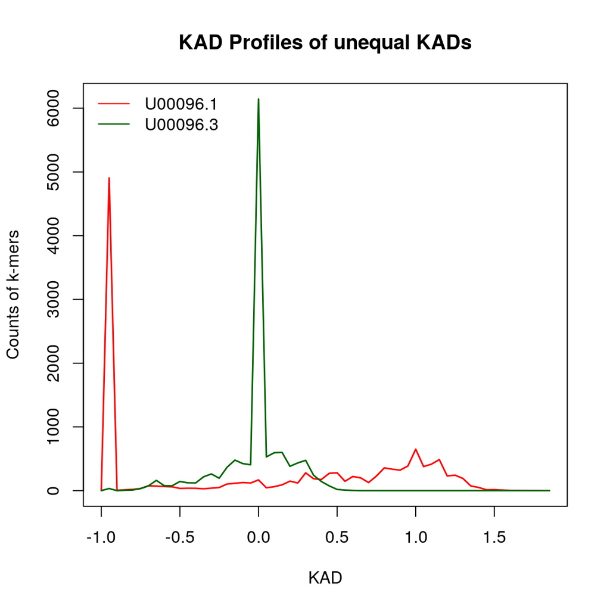

Fig 1. KAD profiles

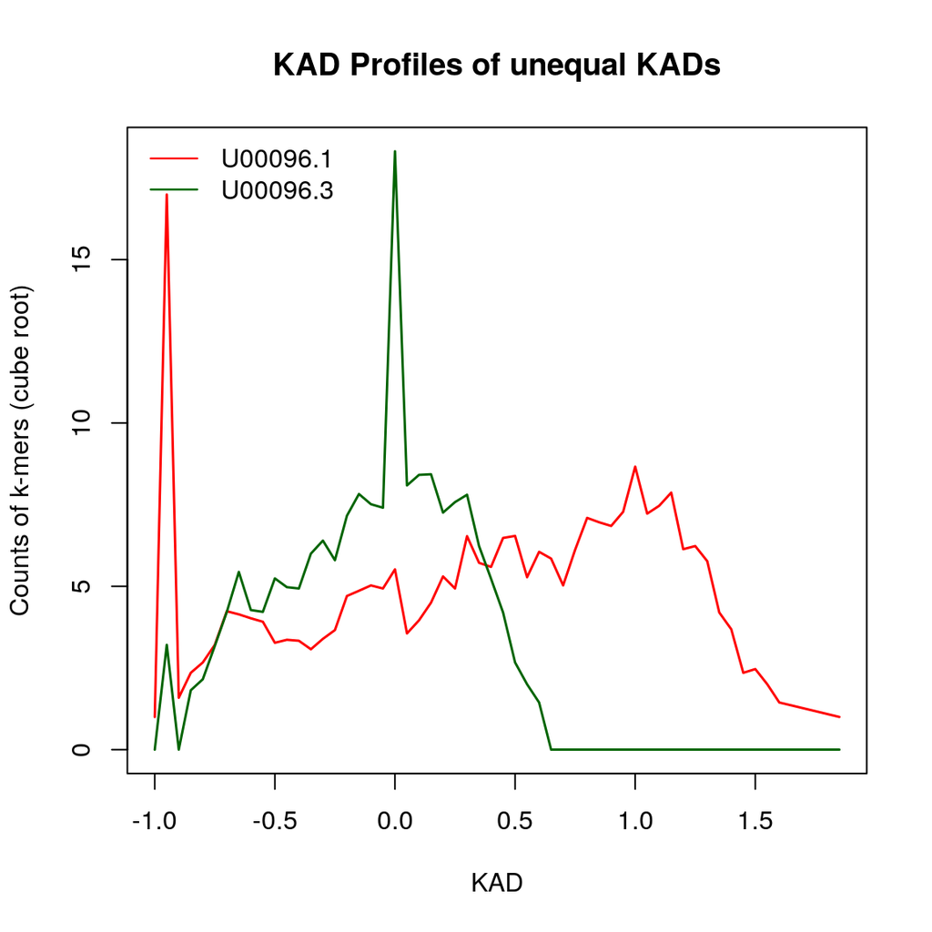

Fig 2. KAD profiles

In the output directory, U00096.1vs3, both figures were separately generated in PDF format.